# InteroMap — Study 1 Report

Pre-registered and exploratory outcomes (linear mixed models)

# Load data and prepare variables

Reads the cleaned, de-identified data frame produced by `interomap_data_prep.R`. Z-scored outcomes are standardised within the whole study, so coefficients are comparable across metrics. Valence and intensity are the per-pixel **average** metrics (`avg_valence_combined`, `avg_intensity_combined`).

```r
df <- read_csv(file.path(base_dir, "data", "processed", "interomap_study1_data.csv"),
               show_col_types = FALSE)

# Private demographics (one row per PID), used only for the Demographics table.
demo_path <- file.path(base_dir, "data", "processed", "interomap_study1_demographics.csv")
have_demographics <- file.exists(demo_path)

if (have_demographics) {
  df <- df |>
    left_join(read_csv(demo_path, show_col_types = FALSE), by = "PID")
} else {
  df <- df |>
    mutate(Age = NA_real_,
           Gender = NA_character_,
           `Cultural background` = NA_character_,
           `Racial lineage` = NA_character_)
}

# Gender coding scheme (code 3 = self-described, free text).
gender_levels <- c("Non-binary", "Woman", "Man", "Self-described/Other",
                   "Don't know", "No answer")

df <- df |>
  mutate(
    # Ensure Gender has every level in the scheme (code 3 is otherwise NA).
    Gender = factor(replace_na(as.character(Gender), "Self-described/Other"),
                    levels = gender_levels),
    # Raw valence/intensity centred at 0 for -5 to +5 descriptives; the 1-11
    # scale is kept for the models (z-scores are shift-invariant).
    avg_valence_centered      = avg_valence_combined - 6,
    avg_intensity_centered    = avg_intensity_combined - 6,
    # Pre-registered outcomes (z-scored for modelling).
    avg_valence_z             = as.numeric(scale(avg_valence_combined)),
    avg_intensity_z           = as.numeric(scale(avg_intensity_combined)),
    extent_log_z              = as.numeric(scale(log(extent_combined + 1))),
    valence_by_extent_log_z   = as.numeric(scale(log(valence_by_extent_combined + 1))),
    intensity_by_extent_log_z = as.numeric(scale(log(intensity_by_extent_combined + 1))),
    # Exploratory spatial outcomes (z-scored for modelling).
    centroid_x_front_z        = as.numeric(scale(centroid_x_front)),
    centroid_y_front_z        = as.numeric(scale(centroid_y_front)),
    sd_x_front_z              = as.numeric(scale(sd_x_front)),
    sd_y_front_z              = as.numeric(scale(sd_y_front)),
    entropy_15_front_z        = as.numeric(scale(entropy_15_front)),
    timepoint = factor(timepoint, levels = c("pre", "post")),
    group     = factor(group, levels = c("non_gambler", "gambler")),
    PID       = factor(PID)
  )

# Raw (untransformed) columns for descriptives and distribution plots.
pre_reg_raw <- c(
  "Average Valence"     = "avg_valence_centered",
  "Average Intensity"   = "avg_intensity_centered",
  "Extent"              = "extent_combined",
  "Valence x Extent"    = "valence_by_extent_combined",
  "Intensity x Extent"  = "intensity_by_extent_combined"
)

exploratory_raw <- c(
  "Centroid x"       = "centroid_x_front",
  "Centroid y"       = "centroid_y_front",
  "SD x"             = "sd_x_front",
  "SD y"             = "sd_y_front",
  "Entropy (15)"     = "entropy_15_front"
)

# Z-scored outcome columns used in the models.
pre_reg_specs <- c(
  "Average Valence"           = "avg_valence_z",
  "Average Intensity"         = "avg_intensity_z",
  "Extent (log)"              = "extent_log_z",
  "Valence x Extent (log)"    = "valence_by_extent_log_z",
  "Intensity x Extent (log)"  = "intensity_by_extent_log_z"
)

exploratory_specs <- c(
  "Centroid x"       = "centroid_x_front_z",
  "Centroid y"       = "centroid_y_front_z",
  "SD x"             = "sd_x_front_z",
  "SD y"             = "sd_y_front_z",
  "Entropy (15)"     = "entropy_15_front_z"
)

all_specs <- c(pre_reg_specs, exploratory_specs)

# LME with Satterthwaite df.
fit_lme <- function(dv, data) {
  lmer(as.formula(paste(dv, "~ timepoint * group + (1 | PID)")),
       data = data, REML = TRUE)
}

# Satterthwaite-df fixed effects, formatted for an APA table (Wald 95% CI).
lme_effects_table <- function(fit) {
  s <- summary(fit)$coefficients
  labels <- c("Intercept", "Timepoint (post)", "Group (gambler)",
              "Timepoint x Group")
  data.frame(
    Parameter = labels,
    b         = round(s[, "Estimate"],   2),
    SE        = round(s[, "Std. Error"], 2),
    df        = round(s[, "df"],         1),
    t         = round(s[, "t value"],    2),
    p         = fmt_p(s[, "Pr(>|t|)"]),
    `95% CI`  = sprintf("[%.2f, %.2f]",
                        s[, "Estimate"] - 1.96 * s[, "Std. Error"],
                        s[, "Estimate"] + 1.96 * s[, "Std. Error"]),
    check.names = FALSE
  )
}

# Mean (+/- 1 SE) by group and timepoint, for a given (z-scored) outcome.
means_plot <- function(data, dv, label) {
  data |>
    group_by(timepoint, group) |>
    summarise(mean = mean(.data[[dv]], na.rm = TRUE),
              se   = sd(.data[[dv]], na.rm = TRUE) / sqrt(n()),
              .groups = "drop") |>
    ggplot(aes(x = timepoint, y = mean, colour = group, group = group)) +
    geom_line() +
    geom_point() +
    geom_errorbar(aes(ymin = mean - se, ymax = mean + se), width = 0.1) +
    labs(x = "Timepoint", y = paste0(label, " (z)"), colour = "Group") +
    theme_minimal()
}

# Histograms of raw values, faceted by metric.
distribution_plot <- function(data, specs) {
  data |>
    select(all_of(unname(specs))) |>
    pivot_longer(everything(), names_to = "metric", values_to = "value") |>
    filter(!is.na(value)) |>
    mutate(metric = factor(metric, levels = unname(specs), labels = names(specs))) |>
    ggplot(aes(x = value)) +
    geom_histogram(bins = 30, fill = "#4A90A4", colour = "white", alpha = 0.85) +
    facet_wrap(~ metric, scales = "free") +
    labs(x = "Raw value", y = "Count") +
    theme_minimal()
}
```

# Demographics and descriptives

Age, gender, and raw outcome descriptives, by gambling group and timepoint. Cultural background and racial lineage are reported in the supplemental.

**Table 1**

*Demographics and Outcome Descriptives by Group and Timepoint (Study 1)*

| Characteristic | Non-Gambler | Gambler |
| --- | --- | --- |
| n | 112 | 113 |
| Age, M (SD) | 38.8 (12.4) | 39.8 (12.1) |
| Gender, n (%) |  |  |
| Woman | 53 (47.3%) | 55 (48.7%) |
| Man | 58 (51.8%) | 57 (50.4%) |
| Non-binary | 1 (0.9%) | 0 (0.0%) |
| No answer | 0 (0.0%) | 1 (0.9%) |
| Average Valence |  |  |
| Pre | -0.14 (2.35) | -0.41 (2.49) |
| Post | -0.51 (2.41) | -0.01 (2.54) |
| Average Intensity |  |  |
| Pre | 1.00 (1.78) | 1.24 (2.10) |
| Post | 0.98 (1.89) | 1.57 (1.81) |
| Extent |  |  |
| Pre | 0.02 (0.03) | 0.02 (0.03) |
| Post | 0.02 (0.03) | 0.02 (0.02) |
| Valence x Extent |  |  |
| Pre | 4536.15 (17716.54) | 4432.09 (12517.55) |
| Post | 2990.03 (13674.79) | 2983.32 (6540.33) |
| Intensity x Extent |  |  |
| Pre | 4374.31 (13879.97) | 6258.77 (17098.91) |
| Post | 3557.08 (9993.50) | 4359.66 (11413.89) |
| Centroid x |  |  |
| Pre | 210.36 (34.93) | 208.69 (26.94) |
| Post | 209.19 (47.18) | 211.05 (29.63) |
| Centroid y |  |  |
| Pre | 361.77 (189.60) | 327.13 (151.73) |
| Post | 305.73 (191.22) | 268.45 (141.94) |
| SD x |  |  |
| Pre | 43.89 (31.54) | 43.52 (28.24) |
| Post | 37.06 (31.74) | 36.43 (27.77) |
| SD y |  |  |
| Pre | 114.28 (98.53) | 135.48 (99.73) |
| Post | 100.52 (96.18) | 98.99 (94.50) |
| Entropy (15) |  |  |
| Pre | 2.15 (0.86) | 2.36 (0.84) |
| Post | 1.95 (0.91) | 2.09 (0.90) |

*Note.* Average Valence and Average Intensity are per-pixel means on a -5 to +5 scale (0 = midpoint). Valence × Extent and Intensity × Extent are raw summed products (heavily right-skewed; log-transformed for analysis). Cell *n*s are slightly below the group *n* where a participant drew nothing. Extent and the ×-Extent metrics combine front and back views.

# Outcome measures

Definitions of the pre-registered and exploratory outcome metrics.

```r
metric_defs <- data.frame(
  Metric = c(
    "Pre-registered metrics",
    "Average Intensity",
    "Average Valence",
    "Extent",
    "Intensity by extent",
    "Valence by extent",
    "Exploratory metrics",
    "Centroid x",
    "Centroid y",
    "SD x",
    "SD y",
    "Entropy (15-grid)"
  ),
  Definition = c(
    "",
    "(Σ intensity of drawn pixels) / (number of pixels drawn)",
    "(Σ valence of drawn pixels) / (number of pixels drawn)",
    "number of pixels drawn / total number of pixels",
    "(Σ intensity of drawn pixels) × (number of pixels drawn / total number of pixels)",
    "(Σ valence of drawn pixels) × (number of pixels drawn / total number of pixels)",
    "",
    "Mean x-coordinate of drawn pixels: Σxᵢ / n",
    "Mean y-coordinate of drawn pixels: Σyᵢ / n",
    "Standard deviation of pixel x-coordinates: √[Σ(xᵢ − Centroid x)² / (n − 1)]",
    "Standard deviation of pixel y-coordinates: √[Σ(yᵢ − Centroid y)² / (n − 1)]",
    "Shannon entropy of the spatial distribution of drawn pixels: front-view image divided into a 15 × 15 grid; pᵢ = proportion of drawn pixels in cell i; entropy = −Σ pᵢ · log(pᵢ)"
  ),
  check.names = FALSE
)

cat(apa_tab_caption("Outcome Metric Definitions (Study 1)"), "\n")
```

**Table 2**

*Outcome Metric Definitions (Study 1)*

```r
apa_table(metric_defs, "study1_metric_definitions", tab_dir)
```

[1] “

| Pre-registered metrics |  |
| --- | --- |
| Average Intensity | (Σ intensity of drawn pixels) / (number of pixels drawn) |
| Average Valence | (Σ valence of drawn pixels) / (number of pixels drawn) |
| Extent | number of pixels drawn / total number of pixels |
| Intensity by extent | (Σ intensity of drawn pixels) × (number of pixels drawn / total number of pixels) |
| Valence by extent | (Σ valence of drawn pixels) × (number of pixels drawn / total number of pixels) |
| Exploratory metrics |  |
| Centroid x | Mean x-coordinate of drawn pixels: Σxᵢ / n |
| Centroid y | Mean y-coordinate of drawn pixels: Σyᵢ / n |
| SD x | Standard deviation of pixel x-coordinates: √[Σ(xᵢ − Centroid x)² / (n − 1)] |
| SD y | Standard deviation of pixel y-coordinates: √[Σ(yᵢ − Centroid y)² / (n − 1)] |

”

# Distributions

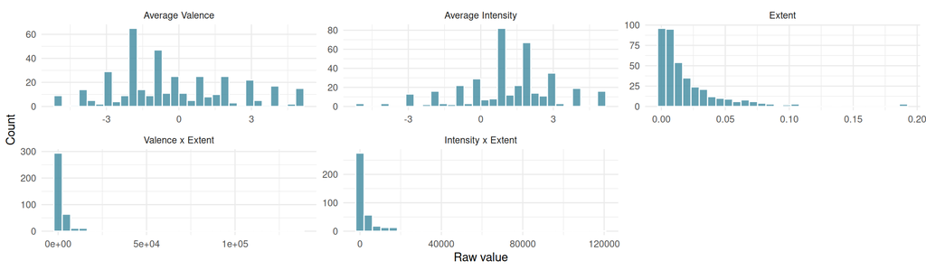

```r
p1 <- distribution_plot(df, pre_reg_raw)
apa_fig(p1, "study1_dist_prereg", fig_dir, width = 12, height = 3.5)
p1
```

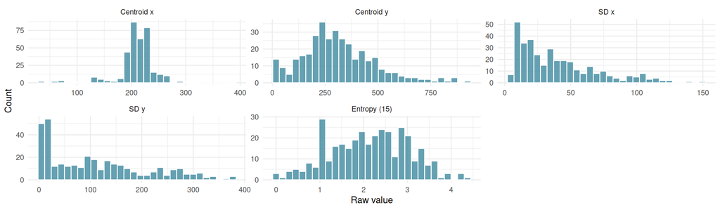

```r
p2 <- distribution_plot(df, exploratory_raw)
apa_fig(p2, "study1_dist_exploratory", fig_dir, width = 12, height = 3.5)
p2
```

# Pre-registered models

Each pre-registered outcome is modelled with

$$\text{outcome}_z \sim \text{timepoint}
\times \text{group} + (1 \mid \text{PID})$$

using `lmerTest::lmer` with Satterthwaite degrees of freedom. Extent and the two extent-products are log-transformed before standardising, to reduce skew.

```r
study1_lme <- setNames(lapply(all_specs, function(dv) fit_lme(dv, df)),
                       all_specs)
```

### Average Valence

**Model:** `avg_valence_z ~ timepoint * group + (1 | PID)`

**Table 3**

*Linear Mixed Model Fixed Effects — Average Valence (Study 1)* [1] “

| Intercept | 0.05 | 0.10 | 338.7 | 0.51 | .613 | [-0.15, 0.25] |
| --- | --- | --- | --- | --- | --- | --- |
| Timepoint (post) | -0.15 | 0.10 | 195.4 | -1.47 | .142 | [-0.36, 0.05] |
| Group (gambler) | -0.10 | 0.14 | 336.9 | -0.74 | .462 | [-0.38, 0.17] |

”

*Note.* b = unstandardised coefficient (outcome in SD units); Wald 95% CI; df = Satterthwaite degrees of freedom.

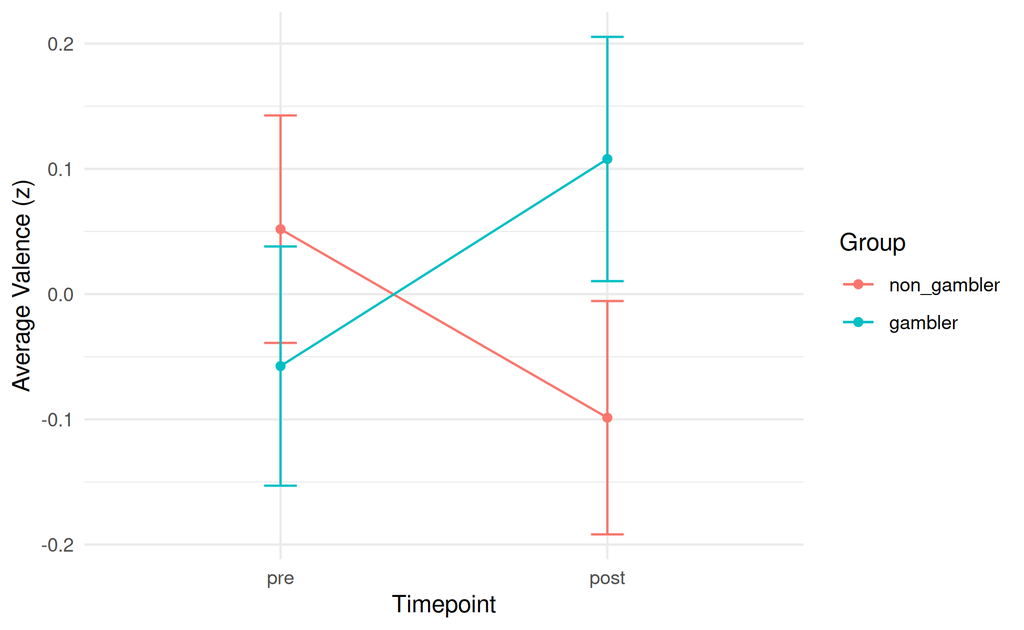

**Figure 1**

*Mean average valence (z-scored) by timepoint and group — Study 1*

### Average Intensity

**Model:** `avg_intensity_z ~ timepoint * group + (1 | PID)`

**Table 4**

*Linear Mixed Model Fixed Effects — Average Intensity (Study 1)* [1] “

| Intercept | -0.12 | 0.10 | 327.3 | -1.14 | .254 | [-0.31, 0.08] |
| --- | --- | --- | --- | --- | --- | --- |
| Timepoint (post) | 0.00 | 0.10 | 187.7 | -0.01 | .994 | [-0.20, 0.20] |
| Group (gambler) | 0.13 | 0.14 | 325.3 | 0.89 | .376 | [-0.15, 0.40] |

”

*Note.* b = unstandardised coefficient (outcome in SD units); Wald 95% CI; df = Satterthwaite degrees of freedom.

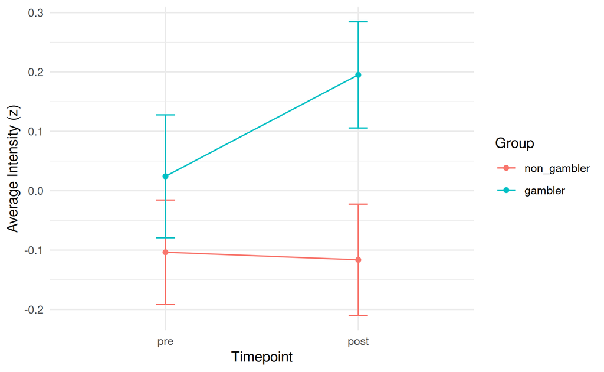

**Figure 2**

*Mean average intensity (z-scored) by timepoint and group — Study 1*

### Extent (log)

**Model:** `extent_log_z ~ timepoint * group + (1 | PID)`

**Table 5**

*Linear Mixed Model Fixed Effects — Extent (log) (Study 1)* [1] “

| Intercept | -0.03 | 0.10 | 267.2 | -0.33 | .740 | [-0.23, 0.16] |
| --- | --- | --- | --- | --- | --- | --- |
| Timepoint (post) | -0.07 | 0.07 | 190.2 | -1.02 | .309 | [-0.21, 0.06] |
| Group (gambler) | 0.13 | 0.14 | 265.5 | 0.91 | .366 | [-0.15, 0.40] |

”

*Note.* b = unstandardised coefficient (outcome in SD units); Wald 95% CI; df = Satterthwaite degrees of freedom.

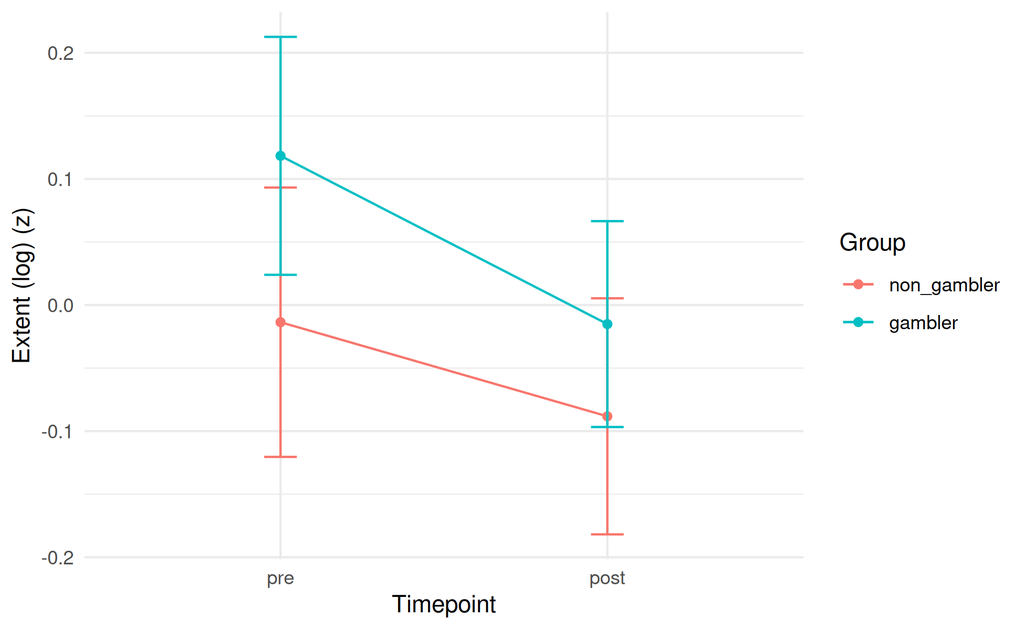

**Figure 3**

*Mean extent (log) (z-scored) by timepoint and group — Study 1*

### Valence x Extent (log)

**Model:** `valence_by_extent_log_z ~ timepoint * group + (1 | PID)`

**Table 6**

*Linear Mixed Model Fixed Effects — Valence x Extent (log) (Study 1)* [1] “

| Intercept | -0.08 | 0.10 | 263.9 | -0.80 | .423 | [-0.28, 0.12] |
| --- | --- | --- | --- | --- | --- | --- |
| Timepoint (post) | -0.13 | 0.07 | 186.7 | -1.92 | .057 | [-0.27, 0.00] |
| Group (gambler) | 0.23 | 0.14 | 262.2 | 1.65 | .101 | [-0.04, 0.51] |

”

*Note.* b = unstandardised coefficient (outcome in SD units); Wald 95% CI; df = Satterthwaite degrees of freedom.

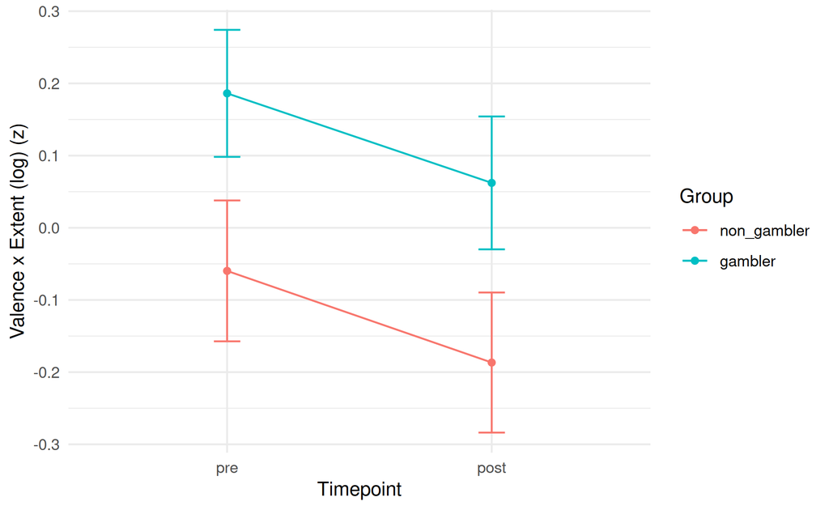

**Figure 4**

*Mean valence x extent (log) (z-scored) by timepoint and group — Study 1*

### Intensity x Extent (log)

**Model:** `intensity_by_extent_log_z ~ timepoint * group + (1 | PID)`

**Table 7**

*Linear Mixed Model Fixed Effects — Intensity x Extent (log) (Study 1)* [1] “

| Intercept | -0.11 | 0.10 | 258.0 | -1.11 | .267 | [-0.31, 0.08] |
| --- | --- | --- | --- | --- | --- | --- |
| Timepoint (post) | -0.09 | 0.07 | 186.4 | -1.44 | .152 | [-0.22, 0.03] |
| Group (gambler) | 0.27 | 0.14 | 256.5 | 1.91 | .057 | [-0.01, 0.54] |

”

*Note.* b = unstandardised coefficient (outcome in SD units); Wald 95% CI; df = Satterthwaite degrees of freedom.

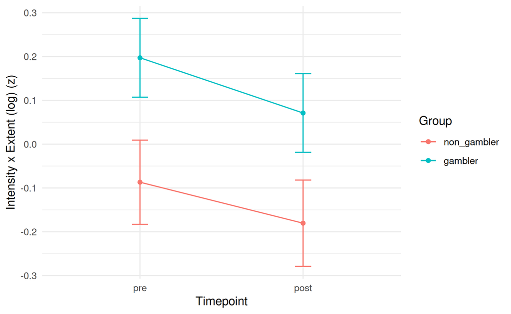

**Figure 5**

*Mean intensity x extent (log) (z-scored) by timepoint and group — Study 1*

# Pre-registered t-tests

For completeness, the t-tests specified in the pre-registration are also reported: a paired t-test of pre vs post within each group, and an independent (Welch) t-test on change scores between groups. The linear mixed models above remain the primary analyses.

```r
run_paired_ttest <- function(data, dv, grp) {
  d <- data |>
    filter(group == grp) |>
    select(PID, timepoint, value = all_of(dv)) |>
    pivot_wider(names_from = timepoint, values_from = value) |>
    filter(!is.na(pre), !is.na(post))
  tt <- t.test(d$post, d$pre, paired = TRUE)
  data.frame(
    group = grp,
    n = nrow(d),
    mean_change = mean(d$post - d$pre),
    t = unname(tt$statistic),
    df = unname(tt$parameter),
    p = tt$p.value,
    ci_lo = tt$conf.int[1],
    ci_hi = tt$conf.int[2]
  )
}

run_between_ttest <- function(data, dv) {
  change <- data |>
    select(PID, group, timepoint, value = all_of(dv)) |>
    pivot_wider(names_from = timepoint, values_from = value) |>
    filter(!is.na(pre), !is.na(post)) |>
    mutate(change = post - pre)
  g  <- change |> filter(group == "gambler")     |> pull(change)
  ng <- change |> filter(group == "non_gambler") |> pull(change)
  tt <- t.test(g, ng, var.equal = FALSE)
  data.frame(
    n_gambler = length(g),
    n_non_gambler = length(ng),
    mean_change_gambler = mean(g),
    mean_change_non_gambler = mean(ng),
    t = unname(tt$statistic),
    df = unname(tt$parameter),
    p = tt$p.value,
    ci_lo = tt$conf.int[1],
    ci_hi = tt$conf.int[2]
  )
}

paired_rows <- lapply(names(pre_reg_specs), function(nm) {
  bind_rows(
    run_paired_ttest(df, pre_reg_specs[[nm]], "gambler"),
    run_paired_ttest(df, pre_reg_specs[[nm]], "non_gambler")
  ) |> mutate(outcome = nm)
}) |> bind_rows()

between_rows <- lapply(names(pre_reg_specs), function(nm) {
  run_between_ttest(df, pre_reg_specs[[nm]]) |> mutate(outcome = nm)
}) |> bind_rows()

paired_tab <- paired_rows |>
  mutate(
    group = factor(group, levels = c("non_gambler", "gambler"),
                   labels = c("Non-Gambler", "Gambler")),
    t = round(t, 2),
    df = round(df, 1),
    p = fmt_p(p),
    `Mean change` = round(mean_change, 2),
    `95% CI` = sprintf("[%.2f, %.2f]", ci_lo, ci_hi)
  ) |>
  select(Outcome = outcome, Group = group, n, `Mean change`, t, df, p, `95% CI`)

between_tab <- between_rows |>
  mutate(
    t = round(t, 2),
    df = round(df, 1),
    p = fmt_p(p),
    `Change, non-gambler` = round(mean_change_non_gambler, 2),
    `Change, gambler` = round(mean_change_gambler, 2),
    `95% CI` = sprintf("[%.2f, %.2f]", ci_lo, ci_hi)
  ) |>
  select(Outcome = outcome, `n (non-gambler)` = n_non_gambler,
         `n (gambler)` = n_gambler, `Change, non-gambler`,
         `Change, gambler`, t, df, p, `95% CI`)

cat(apa_tab_caption("Paired t-Tests (Pre vs Post) by Group \u2014 Study 1"), "\n")
```

**Table 8**

*Paired t-Tests (Pre vs Post) by Group — Study 1*

```r
apa_table(paired_tab, "study1_ttest_paired", tab_dir)
```

[1] “

| Average Valence | Gambler | 93 | 0.14 | 1.31 | 92 | .193 | [-0.07, 0.36] |
| --- | --- | --- | --- | --- | --- | --- | --- |
| Average Valence | Non-Gambler | 93 | -0.16 | -1.55 | 92 | .124 | [-0.36, 0.04] |
| Average Intensity | Gambler | 93 | 0.15 | 1.42 | 92 | .159 | [-0.06, 0.37] |
| Average Intensity | Non-Gambler | 93 | 0.01 | 0.12 | 92 | .906 | [-0.18, 0.20] |
| Extent (log) | Gambler | 93 | -0.10 | -1.34 | 92 | .184 | [-0.24, 0.05] |
| Extent (log) | Non-Gambler | 93 | -0.07 | -1.04 | 92 | .303 | [-0.20, 0.06] |
| Valence x Extent (log) | Gambler | 93 | -0.09 | -1.44 | 92 | .153 | [-0.22, 0.04] |
| Valence x Extent (log) | Non-Gambler | 93 | -0.14 | -1.83 | 92 | .071 | [-0.28, 0.01] |
| Intensity x Extent (log) | Gambler | 93 | -0.10 | -1.57 | 92 | .120 | [-0.22, 0.03] |

”

```r
cat("\n*Note.* Outcomes z-scored within study, so mean change is in SD units. Reported for completeness per the pre-registration; the linear mixed models are the primary analyses.\n\n")
```

*Note.* Outcomes z-scored within study, so mean change is in SD units. Reported for completeness per the pre-registration; the linear mixed models are the primary analyses.

```r
cat(apa_tab_caption("Independent t-Tests on Change Scores (Gambler minus Non-Gambler) \u2014 Study 1"), "\n")
```

**Table 9**

*Independent t-Tests on Change Scores (Gambler minus Non-Gambler) — Study 1*

```r
apa_table(between_tab, "study1_ttest_between", tab_dir)
```

[1] “

| Average Valence | 93 | 93 | -0.16 | 0.14 | 2.02 | 183.2 | .045 | [0.01, 0.60] |
| --- | --- | --- | --- | --- | --- | --- | --- | --- |
| Average Intensity | 93 | 93 | 0.01 | 0.15 | 1.00 | 180.3 | .321 | [-0.14, 0.43] |
| Extent (log) | 93 | 93 | -0.07 | -0.10 | -0.28 | 182.9 | .781 | [-0.22, 0.17] |
| Valence x Extent (log) | 93 | 93 | -0.14 | -0.09 | 0.42 | 181.0 | .674 | [-0.15, 0.24] |

”

```r
cat("\n*Note.* Welch t-test on post - pre change scores (SD units). Reported for completeness per the pre-registration.\n")
```

*Note.* Welch t-test on post - pre change scores (SD units). Reported for completeness per the pre-registration.

# Exploratory models

The same model, applied to the exploratory front-view spatial outcomes.

### Centroid x

**Model:** `centroid_x_front_z ~ timepoint * group + (1 | PID)`

**Table 10**

*Linear Mixed Model Fixed Effects — Centroid x (Study 1)* [1] “

| Intercept | -0.10 | 0.11 | 280.2 | -0.89 | .374 | [-0.31, 0.12] |
| --- | --- | --- | --- | --- | --- | --- |
| Timepoint (post) | 0.08 | 0.10 | 151.0 | 0.77 | .444 | [-0.12, 0.27] |
| Group (gambler) | 0.08 | 0.16 | 279.9 | 0.53 | .599 | [-0.22, 0.39] |

”

*Note.* b = unstandardised coefficient (outcome in SD units); Wald 95% CI; df = Satterthwaite degrees of freedom.

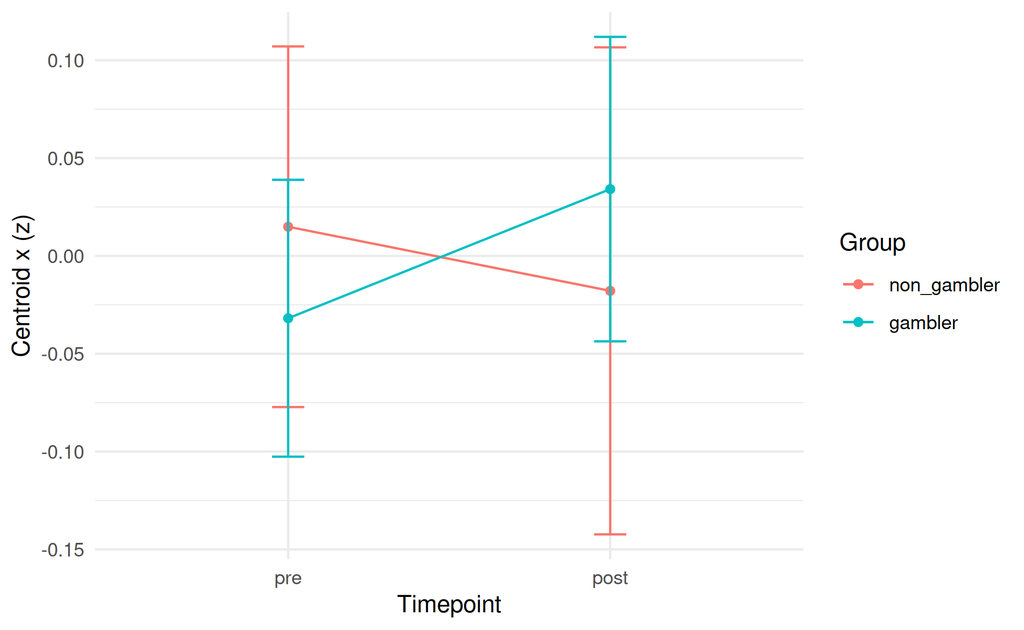

**Figure 6**

*Mean centroid x (z-scored) by timepoint and group — Study 1*

### Centroid y

**Model:** `centroid_y_front_z ~ timepoint * group + (1 | PID)`

**Table 11**

*Linear Mixed Model Fixed Effects — Centroid y (Study 1)* [1] “

| Intercept | 0.29 | 0.10 | 269.3 | 2.84 | .005 | [0.09, 0.50] |
| --- | --- | --- | --- | --- | --- | --- |
| Timepoint (post) | -0.36 | 0.08 | 162.6 | -4.22 | < .001 | [-0.52, -0.19] |
| Group (gambler) | -0.25 | 0.15 | 269.0 | -1.69 | .092 | [-0.54, 0.04] |

”

*Note.* b = unstandardised coefficient (outcome in SD units); Wald 95% CI; df = Satterthwaite degrees of freedom.

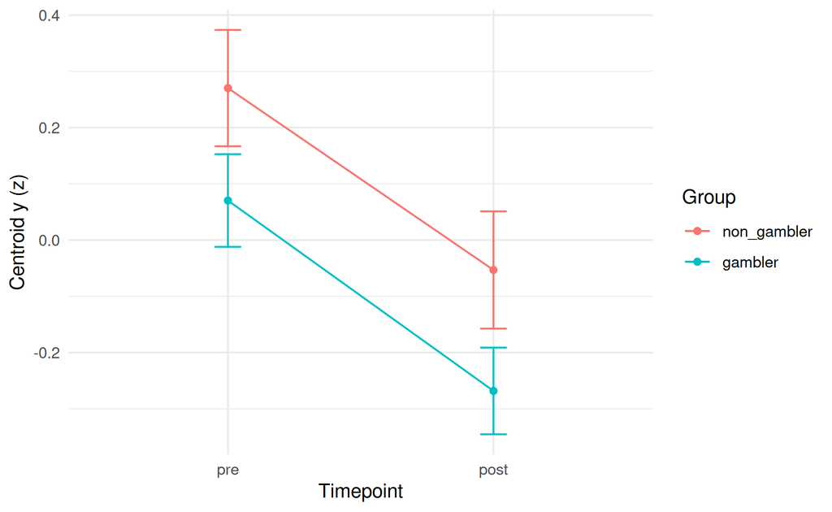

**Figure 7**

*Mean centroid y (z-scored) by timepoint and group — Study 1*

### SD x

**Model:** `sd_x_front_z ~ timepoint * group + (1 | PID)`

**Table 12**

*Linear Mixed Model Fixed Effects — SD x (Study 1)* [1] “

| Intercept | 0.11 | 0.11 | 293.9 | 1.04 | .297 | [-0.10, 0.32] |
| --- | --- | --- | --- | --- | --- | --- |
| Timepoint (post) | -0.23 | 0.10 | 168.5 | -2.28 | .024 | [-0.42, -0.03] |
| Group (gambler) | -0.04 | 0.15 | 293.6 | -0.29 | .772 | [-0.34, 0.25] |

”

*Note.* b = unstandardised coefficient (outcome in SD units); Wald 95% CI; df = Satterthwaite degrees of freedom.

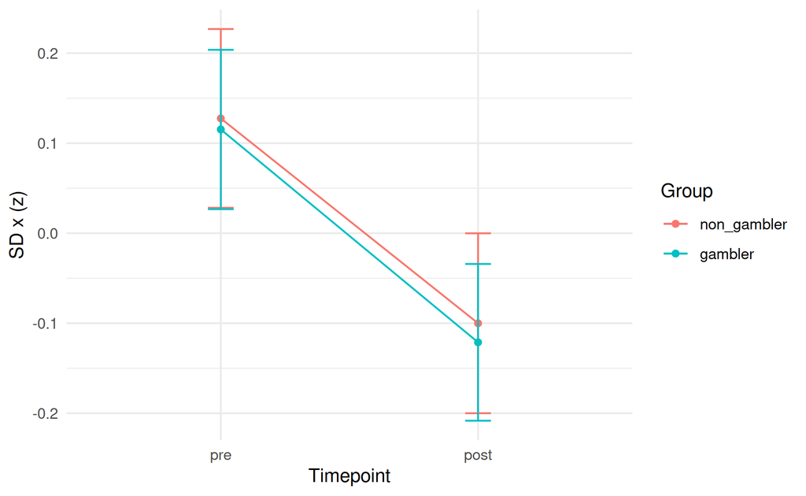

**Figure 8**

*Mean sd x (z-scored) by timepoint and group — Study 1*

### SD y

**Model:** `sd_y_front_z ~ timepoint * group + (1 | PID)`

**Table 13**

*Linear Mixed Model Fixed Effects — SD y (Study 1)* [1] “

| Intercept | -0.01 | 0.10 | 302.2 | -0.13 | .899 | [-0.22, 0.19] |
| --- | --- | --- | --- | --- | --- | --- |
| Timepoint (post) | -0.12 | 0.10 | 173.5 | -1.15 | .250 | [-0.32, 0.08] |
| Group (gambler) | 0.22 | 0.15 | 301.9 | 1.48 | .141 | [-0.07, 0.52] |

”

*Note.* b = unstandardised coefficient (outcome in SD units); Wald 95% CI; df = Satterthwaite degrees of freedom.

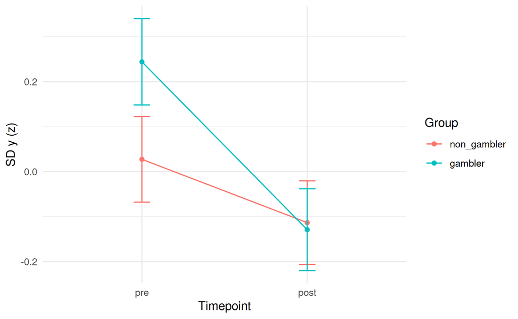

**Figure 9**

*Mean sd y (z-scored) by timepoint and group — Study 1*

### Entropy (15)

**Model:** `entropy_15_front_z ~ timepoint * group + (1 | PID)`

**Table 14**

*Linear Mixed Model Fixed Effects — Entropy (15) (Study 1)* [1] “

| Intercept | -0.03 | 0.10 | 276.9 | -0.31 | .754 | [-0.24, 0.17] |
| --- | --- | --- | --- | --- | --- | --- |
| Timepoint (post) | -0.18 | 0.09 | 161.4 | -2.00 | .047 | [-0.36, -0.00] |
| Group (gambler) | 0.25 | 0.15 | 276.6 | 1.64 | .102 | [-0.05, 0.54] |

”

*Note.* b = unstandardised coefficient (outcome in SD units); Wald 95% CI; df = Satterthwaite degrees of freedom.

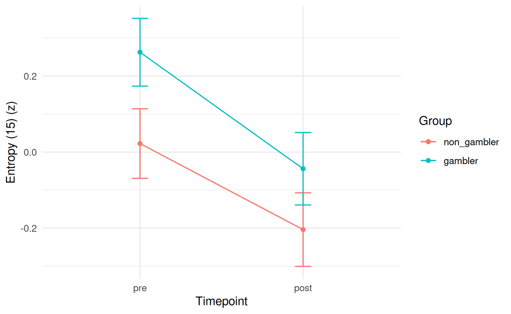

**Figure 10**

*Mean entropy (15) (z-scored) by timepoint and group — Study 1*